# 10X Analysis Template: TCRs

Kirsten Diggins

This template provides code to read, process, and plot TCR counts from 10X analysis. Code for TCR data reading and pre-processing was written by Hannah DeBurg, and airline plot code was written by Matt Dufort. The merging and plotting steps require a post-processed, clustered cds object from GEX analysis.

## Workflow:

1. Load and process TCR counts; get QC plots.
2. Merge TCR libs and run tcrGraph to get clonotypes.
3. Merge TCR data with GEX data for data exploration.
4. Plots to explore clonal expansion.

```r
library(dplyr)
library(ggthemes)
library(ggbeeswarm)
library(viridis)
library(stringr)
library(readxl)
library(kableExtra)
library(RColorBrewer)
library(plotly)
library(tidyr)
library(gtools)
library(apird) #API for the research database
#library(devtools)  #if needed to obtain github packages
# install_github('mjdufort/TCRtools') #if needed to get Matt Dufort's package
library(TCRtools)
# library(annotables)
#devtools::install_github("stephenturner/annotables")
library(RNAseQC) #install_github('benaroyaresearch/RNAseQC')
library(data.table)
library(edgeR)
library(ggrepel)
library(ComplexHeatmap)
library(geneSetTools) # For barcode plots
library(egg) #For ggarrange
library(ggpubr) #Also for ggarrange
library(DGETools) #install_github('benaroyaresearch/DGETools')
library(inlmisc) #For colors
library(umap)
library(tcrGraph)
library(igraph)
library(forcats)
library(ggalluvial)
library(Seurat)
library(monocle3)
```

## Load and process TCR counts; get QC plots

```r
## Set path to data files
# file_path = "my_path/"
file_path = "C:/Users/kdiggins/Box/P362-1 T1DAL 10X/200821-10X_T1DAL_Results/200821-10X_T1DAL_Results/"

## Load annotation file
# load(file_path,"project annotation.Rdata") ## project_anno
load("C:/Users/kdiggins/Box/P362-1 T1DAL 10X/P362-2 annotation.Rdata")
anno_data <- P362_anno ## rename

## Load GEX data (cds object; post-processing with cluster and trajectory information)
# load(paste0(file_path,"cds_object.Rdata"))
load("C:/Users/kdiggins/Box/P362-1 T1DAL 10X/P362-1 T1DAL cds object - postQC no MAIT cells.Rdata")
cds_all <- cds_no_MAIT

## Filter annotation to just TCR libraries
# tcr_anno <- project_anno %>% dplyr::filter(libraryProtocolId=="next_gem_sc_5prime_10x_genomics_tcr_enriched")
tcr_anno <- P362_anno %>% dplyr::filter(libraryProtocolId=="next_gem_sc_5prime_10x_genomics_tcr_enriched") ## library protocol ID

head(tcr_anno)
```

|  | pool | project | sample_name | sample_id | contentType | studyGroup | species | iTNID | participantID | response | sort | cellType | cellNumber | treatment | stimulation | timepoint | visit | dateCollected | dateReceived | cellCountAfterWashResuspCellsUl | cellViability | gateForCellCounter | targetedCellRecovery | sorter | researchers | cDNASampleId | cDNAPgUlFromHSD5000 | cDNATotalYieldNg | cDNAProtocolId | … |
| --- | --- | --- | --- | --- | --- | --- | --- | --- | --- | --- | --- | --- | --- | --- | --- | --- | --- | --- | --- | --- | --- | --- | --- | --- | --- | --- | --- | --- | --- | --- |
| 1 | 1 | P362-1 | 1_1223_TCR | S75900 | Cells | T1D | Human | 961223F07 | 10256 | R | CD3+ CD8+ CD45RA+/- CCR7+/- | Memory T Cell | 50000 | Alefacept | None | Week 104 | 5 | 2020-06-16 17:00:00 | 2020-06-16 17:00:00 | 1040 | 97 | 6-8 | 5000 | Fusion | Bryce Fuchs/Alice Long | cDNA54496 | 4844 | 217.98 | next_gem_sc_5prime_10x_genomics | … |
| 2 | 1 | P362-1 | 2_4505_TCR | S75901 | Cells | T1D | Human | 964505F06 | 10059 | R | CD3+ CD8+ CD45RA+/- CCR7+/- | Memory T Cell | 50000 | Alefacept | None | Week 104 | 5 | 2020-06-16 17:00:00 | 2020-06-16 17:00:00 | 999 | 88 | 6-8 | 5000 | Fusion | Bryce Fuchs/Alice Long | cDNA54497 | 3780 | 170.10 | next_gem_sc_5prime_10x_genomics | … |
| 3 | 1 | P362-1 | 3_4509_TCR | S75902 | Cells | T1D | Human | 964509F06 | 10289 | NR | CD3+ CD8+ CD45RA+/- CCR7+/- | Memory T Cell | 50000 | Alefacept | None | Week 104 | 5 | 2020-06-16 17:00:00 | 2020-06-16 17:00:00 | 1030 | 80 | 6-8 | 5000 | Fusion | Bryce Fuchs/Alice Long | cDNA54498 | 6410 | 288.45 | next_gem_sc_5prime_10x_genomics | … |
| 4 | 1 | P362-1 | 4_4611_TCR | S75903 | Cells | T1D | Human | 964611F07 | 10497 | NR | CD3+ CD8+ CD45RA+/- CCR7+/- | Memory T Cell | 50000 | Alefacept | None | Week 104 | 5 | 2020-06-16 17:00:00 | 2020-06-16 17:00:00 | 982 | 96 | 6-8 | 5000 | Fusion | Bryce Fuchs/Alice Long | cDNA54499 | 5460 | 245.70 | next_gem_sc_5prime_10x_genomics | … |
| 5 | 2 | P362-1 | 5_4546_TCR | S75904 | Cells | T1D | Human | 964546F07 | 10396 | R | CD3+ CD8+ CD45RA+/- CCR7+/- | Memory T Cell | 50000 | Alefacept | None | Week 104 | 5 | 2020-06-16 17:00:00 | 2020-06-16 17:00:00 | 955 | 89 | 6-8 | 5000 | Fusion | Bryce Fuchs/Alice Long | cDNA54500 | 2590 | 116.55 | next_gem_sc_5prime_10x_genomics | … |
| 6 | 2 | P362-1 | 6_8083_TCR | S75905 | Cells | T1D | Human | 968083F05 | 10469 | NR | CD3+ CD8+ CD45RA+/- CCR7+/- | Memory T Cell | 50000 | Alefacept | None | Week 104 | 5 | 2020-06-16 17:00:00 | 2020-06-16 17:00:00 | 1240 | 90 | 6-8 | 5000 | Fusion | Bryce Fuchs/Alice Long | cDNA54501 | 2530 | 113.85 | next_gem_sc_5prime_10x_genomics | … |

Read in individual TCR data files (anno, clonotypes, metrics) and merge into aggregated objects:

```r
## Get TCR library IDs
libs <- tcr_anno %>% dplyr::select(libid)
libs <- as.vector(libs$libid)

tcr_files <- file.path(file_path, "individualLibraryResults","tcr", paste0(libs, "_all_contig_annotations.csv"))
clonotype_files <- file.path(file_path, "individualLibraryResults","tcr", paste0(libs, "_clonotypes.csv"))
tcr_qc_files <- file.path(file_path, "individualLibraryResults","tcr", paste0(libs, "_metrics_summary.csv"))

unpack_file <- function(file_in){

  data <- read.csv(file_in)
  data$libid <- str_extract(file_in, "lib[0-9]+")

  return(data)

}

tcrs_list <- lapply(tcr_files, unpack_file)
tcrs <- bind_rows(tcrs_list)

clonotypes_list <- lapply(clonotype_files, unpack_file)
clonotypes <- bind_rows(clonotypes_list)

## Extract and bind all tcr metrics
tcr_metrics <- lapply(tcr_qc_files, unpack_file)

## Fix character conversion of estimated number of cells in files
make_char_numeric <- function(file_in){
  in_file <- file_in
  in_file$Mean.Read.Pairs.per.Cell <- as.numeric(str_remove(in_file$Mean.Read.Pairs.per.Cell,","))
  in_file$Mean.Read.Pairs.per.Cell <- as.numeric(str_remove(in_file$Mean.Read.Pairs.per.Cell,","))
  in_file$Estimated.Number.of.Cells <- as.numeric(str_remove(in_file$Estimated.Number.of.Cells,","))
  in_file$Number.of.Cells.With.Productive.V.J.Spanning.Pair <- as.numeric(str_remove(in_file$Number.of.Cells.With.Productive.V.J.Spanning.Pair,","))

  return(in_file)
}

tcr_metrics <- lapply(tcr_metrics,make_char_numeric)

tcr_metrics <- bind_rows(tcr_metrics)
head(tcr_metrics)
```

|  | Estimated.Number.of.Cells | Mean.Read.Pairs.per.Cell | Number.of.Cells.With.Productive.V.J.Spanning.Pair | Number.of.Read.Pairs | Valid.Barcodes | Q30.Bases.in.Barcode | Q30.Bases.in.RNA.Read.1 | Q30.Bases.in.UMI | Reads.Mapped.to.Any.V.D.J.Gene | Reads.Mapped.to.TRA | Reads.Mapped.to.TRB | Mean.Used.Read.Pairs.per.Cell | Fraction.Reads.in.Cells | Median.TRA.UMIs.per.Cell | Median.TRB.UMIs.per.Cell | Cells.With.Productive.V.J.Spanning.Pair | Cells.With.Productive.V.J.Spanning..TRA..TRB..Pair | Paired.Clonotype.Diversity | Cells.With.TRA.Contig | Cells.With.TRB.Contig | Cells.With.CDR3.annotated.TRA.Contig | Cells.With.CDR3.annotated.TRB.Contig | Cells.With.V.J.Spanning.TRA.Contig | Cells.With.V.J.Spanning.TRB.Contig | Cells.With.Productive.TRA.Contig | Cells.With.Productive.TRB.Contig | libid |
| --- | --- | --- | --- | --- | --- | --- | --- | --- | --- | --- | --- | --- | --- | --- | --- | --- | --- | --- | --- | --- | --- | --- | --- | --- | --- | --- | --- |
| 1 | 1018 | 19454 | 450 | 19,805,146 | 90.1% | 91.6% | 87.6% | 90.1% | 74.9% | 20.0% | 54.7% | 6,488 | 43.6% | 1 | 4 | 44.2% | 44.2% | 148.90 | 62.6% | 93.3% | 56.9% | 92.1% | 61.1% | 92.2% | 52.8% | 91.4% | lib48841 |
| 2 | 525 | 39680 | 106 | 20,832,220 | 89.6% | 91.5% | 88.0% | 89.9% | 73.5% | 14.6% | 58.9% | 7,820 | 24.8% | 0 | 4 | 20.2% | 20.2% | 51.07 | 38.3% | 97.9% | 29.9% | 97.3% | 37.3% | 97.7% | 23.0% | 97.1% | lib48842 |
| 3 | 893 | 22387 | 352 | 19,991,998 | 89.9% | 91.5% | 88.1% | 90.1% | 76.4% | 17.9% | 58.4% | 5,165 | 29.9% | 1 | 4 | 39.4% | 39.4% | 276.57 | 58.5% | 96.6% | 51.4% | 95.6% | 57.1% | 96.1% | 44.2% | 95.2% | lib48843 |
| 4 | 775 | 25616 | 266 | 19,852,758 | 89.2% | 91.5% | 87.9% | 90.1% | 74.7% | 16.2% | 58.4% | 6,018 | 29.9% | 1 | 4 | 34.3% | 34.3% | 20.58 | 53.5% | 91.9% | 49.2% | 90.8% | 53.0% | 91.0% | 44.1% | 90.2% | lib48844 |
| 5 | 1325 | 17832 | 590 | 23,627,739 | 92.0% | 91.0% | 87.7% | 89.4% | 78.5% | 21.8% | 56.4% | 5,603 | 39.5% | 1 | 4 | 44.5% | 44.5% | 56.86 | 63.6% | 94.0% | 57.0% | 92.9% | 62.3% | 93.1% | 52.5% | 92.0% | lib48845 |
| 6 | 694 | 32903 | 225 | 22,835,309 | 92.7% | 91.0% | 87.9% | 89.4% | 82.1% | 11.3% | 70.7% | 5,681 | 21.0% | 0 | 5 | 32.4% | 32.4% | 48.26 | 40.6% | 99.1% | 36.6% | 98.8% | 39.5% | 98.8% | 33.9% | 98.4% | lib48846 |

# Data quality metrics

```r
make_pct_numeric <- function(pct_column){

  num_column <- pct_column %>%
    str_remove_all("%") %>%
    as.numeric()
  num_column <- num_column/100

  return(num_column)
}

tcr_metrics <- tcr_metrics %>%
  dplyr::mutate(Reads.Mapped.to.Any.V.D.J.Gene = make_pct_numeric(Reads.Mapped.to.Any.V.D.J.Gene),
                Cells.With.Productive.TRA.Contig = make_pct_numeric(Cells.With.Productive.TRA.Contig),
                Cells.With.Productive.TRB.Contig = make_pct_numeric(Cells.With.Productive.TRB.Contig))

tcr_anno_metrics <- merge(tcr_anno,tcr_metrics,by="libid")
head(tcr_anno_metrics)
```

|  | libid | pool | project | sample_name | sample_id | contentType | studyGroup | species | iTNID | participantID | response | sort | cellType | cellNumber | treatment | stimulation | timepoint | visit | dateCollected | dateReceived | cellCountAfterWashResuspCellsUl | cellViability | gateForCellCounter | targetedCellRecovery | sorter | researchers | cDNASampleId | cDNAPgUlFromHSD5000 | cDNATotalYieldNg | … |
| --- | --- | --- | --- | --- | --- | --- | --- | --- | --- | --- | --- | --- | --- | --- | --- | --- | --- | --- | --- | --- | --- | --- | --- | --- | --- | --- | --- | --- | --- | --- |
| 1 | lib48841 | 1 | P362-1 | 1_1223_TCR | S75900 | Cells | T1D | Human | 961223F07 | 10256 | R | CD3+ CD8+ CD45RA+/- CCR7+/- | Memory T Cell | 50000 | Alefacept | None | Week 104 | 5 | 2020-06-16 17:00:00 | 2020-06-16 17:00:00 | 1040 | 97 | 6-8 | 5000 | Fusion | Bryce Fuchs/Alice Long | cDNA54496 | 4844 | 217.98 | … |
| 2 | lib48842 | 1 | P362-1 | 2_4505_TCR | S75901 | Cells | T1D | Human | 964505F06 | 10059 | R | CD3+ CD8+ CD45RA+/- CCR7+/- | Memory T Cell | 50000 | Alefacept | None | Week 104 | 5 | 2020-06-16 17:00:00 | 2020-06-16 17:00:00 | 999 | 88 | 6-8 | 5000 | Fusion | Bryce Fuchs/Alice Long | cDNA54497 | 3780 | 170.10 | … |
| 3 | lib48843 | 1 | P362-1 | 3_4509_TCR | S75902 | Cells | T1D | Human | 964509F06 | 10289 | NR | CD3+ CD8+ CD45RA+/- CCR7+/- | Memory T Cell | 50000 | Alefacept | None | Week 104 | 5 | 2020-06-16 17:00:00 | 2020-06-16 17:00:00 | 1030 | 80 | 6-8 | 5000 | Fusion | Bryce Fuchs/Alice Long | cDNA54498 | 6410 | 288.45 | … |
| 4 | lib48844 | 1 | P362-1 | 4_4611_TCR | S75903 | Cells | T1D | Human | 964611F07 | 10497 | NR | CD3+ CD8+ CD45RA+/- CCR7+/- | Memory T Cell | 50000 | Alefacept | None | Week 104 | 5 | 2020-06-16 17:00:00 | 2020-06-16 17:00:00 | 982 | 96 | 6-8 | 5000 | Fusion | Bryce Fuchs/Alice Long | cDNA54499 | 5460 | 245.70 | … |
| 5 | lib48845 | 2 | P362-1 | 5_4546_TCR | S75904 | Cells | T1D | Human | 964546F07 | 10396 | R | CD3+ CD8+ CD45RA+/- CCR7+/- | Memory T Cell | 50000 | Alefacept | None | Week 104 | 5 | 2020-06-16 17:00:00 | 2020-06-16 17:00:00 | 955 | 89 | 6-8 | 5000 | Fusion | Bryce Fuchs/Alice Long | cDNA54500 | 2590 | 116.55 | … |
| 6 | lib48846 | 2 | P362-1 | 6_8083_TCR | S75905 | Cells | T1D | Human | 968083F05 | 10469 | NR | CD3+ CD8+ CD45RA+/- CCR7+/- | Memory T Cell | 50000 | Alefacept | None | Week 104 | 5 | 2020-06-16 17:00:00 | 2020-06-16 17:00:00 | 1240 | 90 | 6-8 | 5000 | Fusion | Bryce Fuchs/Alice Long | cDNA54501 | 2530 | 113.85 | … |

# Get TCR metrics plots

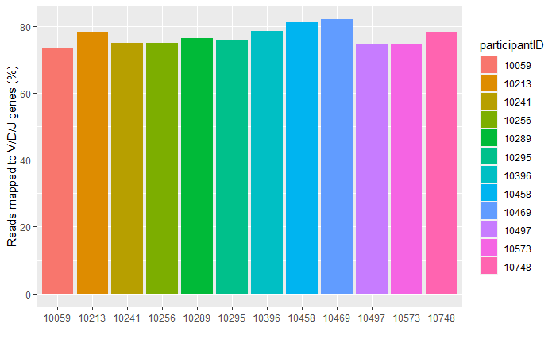

```r
ggplot(tcr_anno_metrics) +
  geom_col(aes(x = participantID,
                 y = Reads.Mapped.to.Any.V.D.J.Gene*100,
               fill = participantID))+
  labs(x = "",
       y = "Reads mapped to V/D/J genes (%)")
```

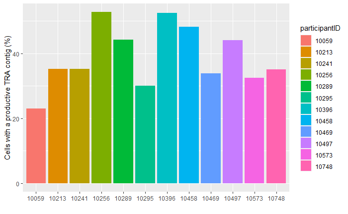

```r
ggplot(tcr_anno_metrics) +
  geom_col(aes(x = participantID,
                 y = Cells.With.Productive.TRA.Contig*100,
               fill = participantID))+
  labs(x = "",
       y = "Cells with a productive TRA contig (%)")
```

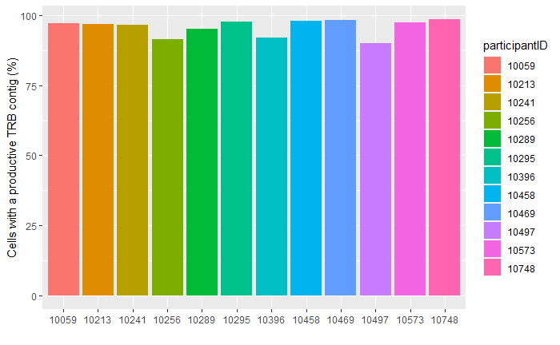

```r
ggplot(tcr_anno_metrics) +
  geom_col(aes(x = participantID,
                 y = Cells.With.Productive.TRB.Contig*100,
               fill = participantID))+
  labs(x = "",
       y = "Cells with a productive TRB contig (%)")
```

```r
# save(tcrs,file=paste0(file_path,"per-cell TCR data - postQC.Rdata"))
```

## Merge TCR libs and run tcrGraph to get clonotypes

```r
## Load per-cell, post-QC TCR data (generated by code above)
# load(paste0(file_path,"per-cell TCR data - postQC.Rdata"))

## Load project annotation if not loaded above
# load(paste0(file_path,"annotation.Rdata"))
# anno_data <- project_anno
```

Barcode IDs may be repeated across flow cells, so to be sure that each cell has a unique ID, first append cell barcode to donor ID and rename to “libid” (for use in tcrGraph).

[output not shown]

# Run tcrGraph on combined samples to get global clonotype definitions.

```r
length(unique(tcrGraph_clones_all$cloneId)) ## check number of clonotypes identified
```

```
[1] 10178
```

## Merge TCR info with GEX data for data exploration

Add back tcrGraph clonotype ID to cds colData for plotting: reformat tcrGraph clone IDs and sequence information to merge with cds.

The barcode suffix (-1,-2, etc) designates the GEM well. The samples in this experiment were each run in a single GEM well, so in the raw data this should be just -1 across the board. However, in the GEX aggregation step, it seems to be iteratively increasing the suffix with each additional library. So, to merge TCR barcodes with aggregated GEX barcodes, it’s necessary to remove the suffix.

```r
all_cloneID_data = data.frame(barcode_donorID = NULL,
                             Donor.ID = NULL,
                             barcode = NULL,
                             cloneID = NULL,
                             clone_count = NULL,
                             vGenes = NULL,
                             jGenes = NULL,
                             cdr3_nt = NULL)

for(i in 1:length(unique(tcrGraph_clones_all$cloneId))){
  single_clone_data <- tcrGraph_clones_all[i,]

  ## Extract IDs
  both_IDs = unlist(str_split(single_clone_data$libs, ", "))
  Donor.IDs =  sapply(strsplit(both_IDs, "_"), `[`, 2)
  barcodes_long = sapply(strsplit(both_IDs, "_"), `[`, 1)
  barcodes = sapply(strsplit(barcodes_long,"-"), `[`, 1)

  ## Build single clone data frame
  single_clone <- data.frame(barcode_donorID = paste(barcodes,Donor.IDs,sep="_"),
                             Donor.ID = Donor.IDs,
                             barcode_original = barcodes_long,
                             barcode = barcodes,
                             cloneID = single_clone_data$cloneId,
                             clone_count = single_clone_data$cloneCounts,
                             vGenes = single_clone_data$vGenes,
                             jGenes = single_clone_data$jGenes,
                             cdr3_nt = single_clone_data$cdr3_nt)

  all_cloneID_data <- bind_rows(all_cloneID_data,single_clone)
}
head(all_cloneID_data)
```

|  | barcode_donorID | Donor.ID | barcode_original | barcode | cloneID | clone_count | vGenes | jGenes | cdr3_nt |
| --- | --- | --- | --- | --- | --- | --- | --- | --- | --- |
| 1 | AGTTGGTTCACATAGC_10256 | 10256 | AGTTGGTTCACATAGC-1 | AGTTGGTTCACATAGC | clone1 | 450 | TRAV1-2, TRBV7-9, TRBV20-1, TRAV12-3 | TRAJ33, TRBJ1-4, TRBJ1-2, TRAJ17 | TGTGCTGTGAGAGATAGCAACTATCAGTTAATCTGG, TGTGCCAGCAGCTTAGCCCTCCTTCGTTTCCGGGGCCCTGCTGGGAATGAAAAACTGTTTTTT, TGCAGTGCCCGCCGGGACAGGGGTGAGGTTTATGGCTACACCTTC, TGTGCAATGAGCGCGGGAGCTGCAGGCAACAAGCTAACTTTT |
| 2 | ATCTGCCCACTAAGTC_10256 | 10256 | ATCTGCCCACTAAGTC-1 | ATCTGCCCACTAAGTC | clone1 | 450 | TRAV1-2, TRBV7-9, TRBV20-1, TRAV12-3 | TRAJ33, TRBJ1-4, TRBJ1-2, TRAJ17 | TGTGCTGTGAGAGATAGCAACTATCAGTTAATCTGG, TGTGCCAGCAGCTTAGCCCTCCTTCGTTTCCGGGGCCCTGCTGGGAATGAAAAACTGTTTTTT, TGCAGTGCCCGCCGGGACAGGGGTGAGGTTTATGGCTACACCTTC, TGTGCAATGAGCGCGGGAGCTGCAGGCAACAAGCTAACTTTT |
| 3 | TCTTCGGCACAGGCCT_10256 | 10256 | TCTTCGGCACAGGCCT-1 | TCTTCGGCACAGGCCT | clone1 | 450 | TRAV1-2, TRBV7-9, TRBV20-1, TRAV12-3 | TRAJ33, TRBJ1-4, TRBJ1-2, TRAJ17 | TGTGCTGTGAGAGATAGCAACTATCAGTTAATCTGG, TGTGCCAGCAGCTTAGCCCTCCTTCGTTTCCGGGGCCCTGCTGGGAATGAAAAACTGTTTTTT, TGCAGTGCCCGCCGGGACAGGGGTGAGGTTTATGGCTACACCTTC, TGTGCAATGAGCGCGGGAGCTGCAGGCAACAAGCTAACTTTT |
| 4 | AGGCCGTAGGGATACC_10059 | 10059 | AGGCCGTAGGGATACC-1 | AGGCCGTAGGGATACC | clone1 | 450 | TRAV1-2, TRBV7-9, TRBV20-1, TRAV12-3 | TRAJ33, TRBJ1-4, TRBJ1-2, TRAJ17 | TGTGCTGTGAGAGATAGCAACTATCAGTTAATCTGG, TGTGCCAGCAGCTTAGCCCTCCTTCGTTTCCGGGGCCCTGCTGGGAATGAAAAACTGTTTTTT, TGCAGTGCCCGCCGGGACAGGGGTGAGGTTTATGGCTACACCTTC, TGTGCAATGAGCGCGGGAGCTGCAGGCAACAAGCTAACTTTT |
| 5 | AGTAGTCCAAGCTGGA_10059 | 10059 | AGTAGTCCAAGCTGGA-1 | AGTAGTCCAAGCTGGA | clone1 | 450 | TRAV1-2, TRBV7-9, TRBV20-1, TRAV12-3 | TRAJ33, TRBJ1-4, TRBJ1-2, TRAJ17 | TGTGCTGTGAGAGATAGCAACTATCAGTTAATCTGG, TGTGCCAGCAGCTTAGCCCTCCTTCGTTTCCGGGGCCCTGCTGGGAATGAAAAACTGTTTTTT, TGCAGTGCCCGCCGGGACAGGGGTGAGGTTTATGGCTACACCTTC, TGTGCAATGAGCGCGGGAGCTGCAGGCAACAAGCTAACTTTT |
| 6 | CAGTCCTAGCCATCGC_10059 | 10059 | CAGTCCTAGCCATCGC-1 | CAGTCCTAGCCATCGC | clone1 | 450 | TRAV1-2, TRBV7-9, TRBV20-1, TRAV12-3 | TRAJ33, TRBJ1-4, TRBJ1-2, TRAJ17 | TGTGCTGTGAGAGATAGCAACTATCAGTTAATCTGG, TGTGCCAGCAGCTTAGCCCTCCTTCGTTTCCGGGGCCCTGCTGGGAATGAAAAACTGTTTTTT, TGCAGTGCCCGCCGGGACAGGGGTGAGGTTTATGGCTACACCTTC, TGTGCAATGAGCGCGGGAGCTGCAGGCAACAAGCTAACTTTT |

```r
## Reformat colData(cds_all) for merging with TCR data
colData(cds_all)$barcode_original <- row.names(colData(cds_all))
cds_metadata <- colData(cds_all) %>% as.data.frame() %>% select(Donor.ID,barcode_original)
cds_metadata$barcode <-  sapply(strsplit(cds_metadata$barcode_original,"-"), `[`, 1)
cds_metadata$barcode_donorID <- paste(cds_metadata$barcode,cds_metadata$Donor.ID,sep="_")
cds_metadata <- cds_metadata %>% select(-barcode) ## to avoid redundancy in merged colData
head(cds_metadata)
```

|  | Donor.ID | barcode_original | barcode_donorID |
| --- | --- | --- | --- |
| AAACCTGAGCACCGCT-1 | 10256 | AAACCTGAGCACCGCT-1 | AAACCTGAGCACCGCT_10256 |
| AAACCTGGTCGTCTTC-1 | 10256 | AAACCTGGTCGTCTTC-1 | AAACCTGGTCGTCTTC_10256 |
| AAACCTGTCTCCCTGA-1 | 10256 | AAACCTGTCTCCCTGA-1 | AAACCTGTCTCCCTGA_10256 |
| AAACGGGAGTGCGATG-1 | 10256 | AAACGGGAGTGCGATG-1 | AAACGGGAGTGCGATG_10256 |
| AAACGGGGTACAAGTA-1 | 10256 | AAACGGGGTACAAGTA-1 | AAACGGGGTACAAGTA_10256 |
| AAACGGGTCCAGTAGT-1 | 10256 | AAACGGGTCCAGTAGT-1 | AAACGGGTCCAGTAGT_10256 |

Create cds metadata object with clone information in same order, same dimensions as colData(cds). If you try to directly merge clone info with cds metadata and then add back the new colData(cds) data frame, this creates row name issues. I’ve found it easier to add columns to colData rather than replace the whole thing.

```r
## Merge colData(cds_all) with TCR info by barcode and Donor ID; if there's a matching barcode and ID between GEX and TCR lib, it will merge, otherwise those fields will be NA
all_cloneID_data_to_merge <- all_cloneID_data %>% dplyr::select(-barcode_original,-Donor.ID)
cds_metadata_with_clones <- left_join(cds_metadata,all_cloneID_data_to_merge, by = "barcode_donorID")

cds_metadata_with_clones
```

| Donor.ID | barcode_original | barcode_donorID | barcode | cloneID | clone_count | vGenes | jGenes | cdr3_nt |
| --- | --- | --- | --- | --- | --- | --- | --- | --- |
| 10256 | AAACCTGAGCACCGCT-1 | AAACCTGAGCACCGCT_10256 | NA | NA | NA | NA | NA | NA |
| 10256 | AAACCTGGTCGTCTTC-1 | AAACCTGGTCGTCTTC_10256 | NA | NA | NA | NA | NA | NA |
| 10256 | AAACCTGTCTCCCTGA-1 | AAACCTGTCTCCCTGA_10256 | NA | NA | NA | NA | NA | NA |
| 10256 | AAACGGGAGTGCGATG-1 | AAACGGGAGTGCGATG_10256 | NA | NA | NA | NA | NA | NA |
| 10256 | AAACGGGGTACAAGTA-1 | AAACGGGGTACAAGTA_10256 | AAACGGGGTACAAGTA | clone8765 | 1 | TRBV20-1 | TRBJ1-1 | TGCAGTGCTAGAGTTCCCGCCTCGGGGAACACTGAAGCTTTCTTT |
| 10256 | AAACGGGTCCAGTAGT-1 | AAACGGGTCCAGTAGT_10256 | NA | NA | NA | NA | NA | NA |
| 10256 | AAAGATGGTCACTGGC-1 | AAAGATGGTCACTGGC_10256 | AAAGATGGTCACTGGC | clone2750 | 16 | TRBV28, TRAV38-2/DV8, TRAV8-3, TRBV13 | TRBJ2-5, TRAJ23, TRAJ10, TRBJ2-7 | TGTGCCAGCAGTCTACCGGCCCTAGGCCACCCAGTTCGAGAGACCCAGTACTTC, TGTGCTTTCTGGGAGGATGGGGGAAAGCTTATCTTC, TGTGCTGTGGGGCCCACGGGAGGAGGAAACAAACTCACCTTT, TGTGCCAGCAGCTGGACCGGGACAGGTTACTACGAGCAGTACTTC |
| 10256 | AAAGATGGTGTGAATA-1 | AAAGATGGTGTGAATA_10256 | AAAGATGGTGTGAATA | clone6896 | 5 | TRAV26-2, TRBV10-3 | TRAJ43, TRBJ2-7 | TGCATCCTGAGAGAAGGCGGCGGGAATGACATGCGCTTT, TGTGCCATCAGTGACCGGGACTTATATTCCGAGCAGTACTTC |
| 10256 | AAAGATGGTTTGACAC-1 | AAAGATGGTTTGACAC_10256 | AAAGATGGTTTGACAC | clone5757 | 3 | TRBV20-1 | TRBJ1-1 | TGCAGTGCTAGGAGGGACAGTATGAACACTGAAGCTTTCTTT |
| 10256 | AAAGATGTCGTTTGCC-1 | AAAGATGTCGTTTGCC_10256 | NA | NA | NA | NA | NA | NA |

[output cut: 990 more lines]

```r
## Check that barcode ID order is the same in the cds metadata object and in colData(cds_all)
all(cds_metadata_with_clones$barcode_original == row.names(colData(cds_all)))
```

```
[1] TRUE
```

```r
## True = TCR and clonotype data is in the same order as the rows in colData(cds)
```

```r
head(colData(cds_all))
```

```
DataFrame with 6 rows and 22 columns
                   orig.ident nCount_RNA nFeature_RNA    gemgroup      Lib.ID    Donor.ID      Pool   Timepoint    Response
                     <factor>  <numeric>    <integer> <character> <character> <character> <integer> <character> <character>
AAACCTGAGCACCGCT-1     P362-1       2998          985           1    lib48853       10256         1    Week 104           R
AAACCTGGTCGTCTTC-1     P362-1       2630          850           1    lib48853       10256         1    Week 104           R
AAACCTGTCTCCCTGA-1     P362-1       2253          893           1    lib48853       10256         1    Week 104           R
AAACGGGAGTGCGATG-1     P362-1        780          339           1    lib48853       10256         1    Week 104           R
AAACGGGGTACAAGTA-1     P362-1       3040         1150           1    lib48853       10256         1    Week 104           R
AAACGGGTCCAGTAGT-1     P362-1       3391         1261           1    lib48853       10256         1    Week 104           R
                        Date.Collected Percent.MT Size_Factor    Batch Cluster.Name   barcode_original     cloneID clone_count      vGenes
                           <character>  <numeric>   <numeric> <factor>     <factor>        <character> <character>   <integer> <character>
AAACCTGAGCACCGCT-1 2020-06-16 17:00:00   10.00667    1.250218        1            3 AAACCTGAGCACCGCT-1          NA          NA          NA
AAACCTGGTCGTCTTC-1 2020-06-16 17:00:00    9.80989    1.096756        1            3 AAACCTGGTCGTCTTC-1          NA          NA          NA
AAACCTGTCTCCCTGA-1 2020-06-16 17:00:00    9.94230    0.939540        1            3 AAACCTGTCTCCCTGA-1          NA          NA          NA
AAACGGGAGTGCGATG-1 2020-06-16 17:00:00    3.46154    0.325274        1            1 AAACGGGAGTGCGATG-1          NA          NA          NA
AAACGGGGTACAAGTA-1 2020-06-16 17:00:00   10.42763    1.267733        1            3 AAACGGGGTACAAGTA-1   clone8765           1    TRBV20-1
AAACGGGTCCAGTAGT-1 2020-06-16 17:00:00    9.67266    1.414106        1            3 AAACGGGTCCAGTAGT-1          NA          NA          NA
                                  cdr3_nt        barcode_donorID clone_count_numeric  cluster
                              <character>            <character>           <numeric> <factor>
AAACCTGAGCACCGCT-1                     NA AAACCTGAGCACCGCT_10256                   0        3
AAACCTGGTCGTCTTC-1                     NA AAACCTGGTCGTCTTC_10256                   0        3
AAACCTGTCTCCCTGA-1                     NA AAACCTGTCTCCCTGA_10256                   0        3
AAACGGGAGTGCGATG-1                     NA AAACGGGAGTGCGATG_10256                   0        1
AAACGGGGTACAAGTA-1 TGCAGTGCTAGAGTTCCCGC.. AAACGGGGTACAAGTA_10256                   1        3
AAACGGGTCCAGTAGT-1                     NA AAACGGGTCCAGTAGT_10256                   0        3
```

## Plots for data exploration

# UMAP plot of cells colored by expansion

Add heat intensity overlay for TCR-expressing cells on UMAP based on clonal expansion.

```
Cells aren't colored in a way that allows them to be grouped.
```

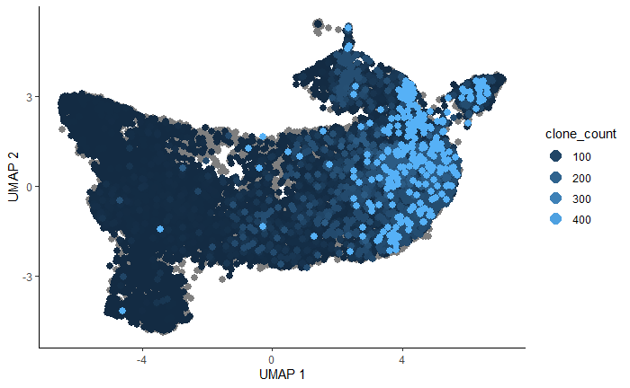

```r
## Replace NA with 0 for clone counts
clone_counts <- colData(cds_all)$clone_count
clone_counts[is.na(clone_counts)] <- 0
colData(cds_all)$clone_count_numeric <- clone_counts
cds_metadata_ordered <- colData(cds_all) %>%
  as.data.frame() %>%
  arrange(clone_count_numeric,) ## reorder so cells with highest clone count are on top

cds_all_ordered <- cds_all[,cds_metadata_ordered$barcode_original]
plot_cells(cds_all_ordered,
           color_cells_by="clone_count",
           show_trajectory_graph = F,
           cell_size=2)
```

```
Cells aren't colored in a way that allows them to be grouped.
```

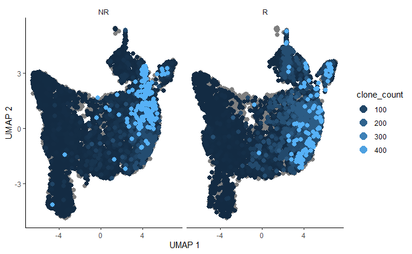

```r
plot_cells(cds_all_ordered,
           color_cells_by="clone_count",
           show_trajectory_graph = F,
           cell_size=2) + facet_wrap(~ Response)
```

# Airline plots - connect cells on UMAP by shared clonotype.

This code was written by Matt Dufort.

```
The `add` argument of `group_by()` is deprecated as of dplyr 1.0.0.
Please use the `.add` argument instead.
```

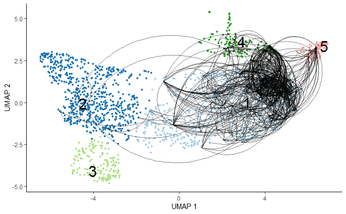

```r
## determine curves to link, based on clone_id_tcr_graph_clonal_expansion
colData(cds_all)$cluster <- colData(cds_all)$Cluster.Name
cds_pc_filtered_align_cdr = cds_all[,sample(colnames(cds_all),2000,replace=F)] ## Downsample large data sets
# make a copy of the annotation plus UMAP coordinates, for easier manipulation
data.tmp <-
  as.data.frame(colData(cds_pc_filtered_align_cdr)) %>%
  cbind(
    as.data.frame(reducedDims(cds_pc_filtered_align_cdr)$UMAP) %>%
      magrittr::set_colnames(c("V1", "V2"))) %>%
  dplyr::rename("clone_id_tcr_graph_clonal_expansion" = "cloneID")

# create data frame to store links
curves.tmp <-
  data.frame(
    clone_id_tcr_graph_clonal_expansion = character(),
    x = numeric(),
    y = numeric(),
    xend = numeric(),
    yend = numeric())

# loop over each clone, and extract coordinates for cells from the same clone
for (clone_id.tmp in na.omit(unique(data.tmp$clone_id_tcr_graph_clonal_expansion))) {
  clone_id_curves.tmp <- curves.tmp[0,]
  data_for_curves.tmp <-
    data.tmp %>%
    dplyr::filter(clone_id_tcr_graph_clonal_expansion %in% clone_id.tmp)
  if (nrow(data_for_curves.tmp) > 1) {
    for (i in 1:(nrow(data_for_curves.tmp)-1)) {
      for (j in (i+1):nrow(data_for_curves.tmp)) {
        clone_id_curves.tmp <-
          rbind(
            clone_id_curves.tmp,
            list(
              clone_id_tcr_graph_clonal_expansion =
                data_for_curves.tmp$clone_id_tcr_graph_clonal_expansion[i],
              x = data_for_curves.tmp$V1[i],
              y = data_for_curves.tmp$V2[i],
              cluster1 = data_for_curves.tmp$cluster[i],
              xend = data_for_curves.tmp$V1[j],
              yend = data_for_curves.tmp$V2[j],
              cluster2 = data_for_curves.tmp$cluster[j]))
      }
    }
  }
  curves.tmp <-
    rbind(curves.tmp, clone_id_curves.tmp)
}

pal.cluster_renumbered = toupper(c('#a6cee3','#1f78b4','#b2df8a','#33a02c','#fb9a99','#e31a1c','#fdbf6f','#ff7f00','#cab2d6','#6a3d9a','#ffed6f','#b15928', "gray","black","blue","red"))
# make the plot
plot_cells(
  cds_pc_filtered_align_cdr,
  color_cells_by = "cluster", cell_size=1, show_trajectory_graph = FALSE,
  group_label_size=8) +
  scale_color_manual(values=pal.cluster_renumbered) +
  geom_curve(
    data = curves.tmp,
    mapping = aes(x=x, y=y, xend=xend, yend=yend),
    size = 0.07,
    alpha=0.5)
```

## Get heatmap of % shared cloneIDs between clusters.

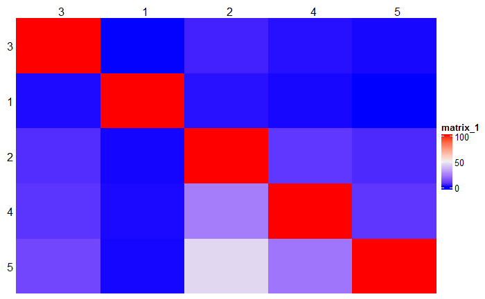

```r
clusters <- unique(colData(cds_all)$Cluster.Name)
percent_shared <- matrix(nrow=length(clusters),ncol=length(clusters))
for(i in 1:length(clusters)){
  for(j in 1:length(clusters)){

    cluster_a <- dplyr::filter(as.data.frame(colData(cds_all)),Cluster.Name==i, !is.na(cloneID)) %>% select(cloneID)
    cluster_b <- dplyr::filter(as.data.frame(colData(cds_all)),Cluster.Name==j, !is.na(cloneID)) %>% select(cloneID)

    shared <- intersect(cluster_a$cloneID,cluster_b$cloneID)
    total_clust_a_clonotypes <- length(unique(cluster_a$cloneID,na.rm=T))
    num_shared_clonotypes <- length(intersect(cluster_a$cloneID,cluster_b$cloneID))
    percent_shared[i,j] <- num_shared_clonotypes/total_clust_a_clonotypes*100
  }
}

colnames(percent_shared) <- clusters
row.names(percent_shared) <- clusters

Heatmap(percent_shared,cluster_rows = F, cluster_columns = F, column_names_rot = F, column_names_side = "top", row_names_side = "left")
```